# DRAFT - Brick colour

Steven Fowler

[figure not shown]

# Lego brick colours

The following is an investigation into lego brick colours. The idea was inspired by Hanna Yan Han’s article [here](https://medium.com/@yanhann10/the-color-history-of-lego-bricks-1e83ffea7b6d). The data for this is from [rebrickable](https://rebrickable.com/). I created a local MySQL DB to access this data (DB set up notes are [here](https://github.com/StevenAFowler/Lego_data/blob/main/Notes.md)).

## What I did

- I explored a Lego database that I previously created (here)
- Initial focus was an exploration into Lego brick colours.
- This led to several questions being raised regarding colours and trends that could be seen over time.
- So, a further investigation looking into three of the previous observations.

## Why I did It

This project was undertaken based on an inspiration from [Hanna Yan Han]](https://medium.com/@yanhann10/the-color-history-of-lego-bricks-1e83ffea7b6d), it provided an interesting set of data to execute my data analysis skills and my life long interest in Lego.

## What I learnt

From focusing on the colour of Lego Bricks:

Looking at sets between 1958 and 1967

- The sets with the most parts were *Deluxe Building Set* and *Starter Train Set with Motor*
- There were 2 sets in database that seem to be place holders for unused parts (*Unused Modulex parts…* & *Unused Parts Database Set…*)
- It can also be seen that themes in this period sometimes related to manufacture i.e *Samsonite*

The Lime bricks from the 80’s that stood out

- The lime coloured bricks were calls *Fabuland Lime* and featured in 5 sets
- Parts included watering can, bathtub and a toilet

Data trends in teh 2000’s

- Generally, there is an increase in themes, sets and colours starting in the mid-1900’s.
- There is also a double peak in new sets in 2000 and 2015, with a dip in number in 2005.
- Based on common knowledge about Lego business struggles at this time and there recovery some correlations were proposed, but without further data could not be verified.

*Default settings are in code chuck below*

```r
# Import Library
library(RMySQL)
library(plotwidgets)
library(ggplot2)
library(reshape2)

# DB connection
source("/Users/steveuser/Documents/Repositories/Lego_data/getDBConn.r")

# Custom plot theme
custom_theme <- function() {
  font <- "Courier"
  theme_light() +
    theme(
      legend.position = "none",
      plot.title = element_text(family = font,
                                size = 16,
                                face = "bold",
                                hjust = 0,
                                vjust = 2),
      plot.subtitle = element_text(family = font,
                                   size = 12),
      plot.caption = element_text(family = font,
                                  size = 9,
                                  hjust = 1),
      axis.title = element_text(family = font,
                                size = 10),
      axis.text = element_text(family = font,
                               size = 9),
      axis.text.x = element_text(margin = margin(5, b = 10))
    )
}
theme_set(custom_theme())
```

# Data processing

The data for all the colour analysis can be found in the ‘colors’ table in the Lego DB. For plotting: The individual colours values for both RGB and HSL were pull out into their own columns. Also, a mapping list was created to map lego brick colour to lego brick colour name (makes life easy when manually setting the colour scale `scale_color_manual()`.)

```r
# Note: 'conn' was generated from a script to hide the user details
#       dbGetQuery is from the 'RMySQL' library which is loaded in the above script

data_from_mysql <- dbGetQuery(conn, "SELECT * FROM colors")

# Split colour values out for plotting
data_from_mysql$rgb_hex <- paste0("#", data_from_mysql$rgb)
# HSL values
data_from_mysql$H <- col2hsl(data_from_mysql$rgb_hex)[1,]
data_from_mysql$S <- col2hsl(data_from_mysql$rgb_hex)[2,]
data_from_mysql$L <- col2hsl(data_from_mysql$rgb_hex)[3,]
# RGB values
data_from_mysql$R <- col2rgb(data_from_mysql$rgb_hex)[1,]
data_from_mysql$G <- col2rgb(data_from_mysql$rgb_hex)[2,]
data_from_mysql$B <- col2rgb(data_from_mysql$rgb_hex)[3,]

# Mapping Lego Brick colour to name for manual scale plotting
fill_colour_value_mapping_byName <- list()
for(i in 1:nrow(data_from_mysql)){
  fill_colour_value_mapping_byName[i] <- data_from_mysql$rgb_hex[i]
}
names(fill_colour_value_mapping_byName) <- data_from_mysql$name

# Addition non-lego brick colours
fill_colour_value_mapping_byName <- append(fill_colour_value_mapping_byName, c(None = NA))
```

# Exploration of the data

The following explores Lego brick colours as well as the addition data incorporated in the ‘colors’ database table, which includes:

- number of parts (`num_parts`)
- number of lego sets (`num_sets`)
- first year intoduced (`y1`)
- last year used (`y2`)

## All the lego brick colours

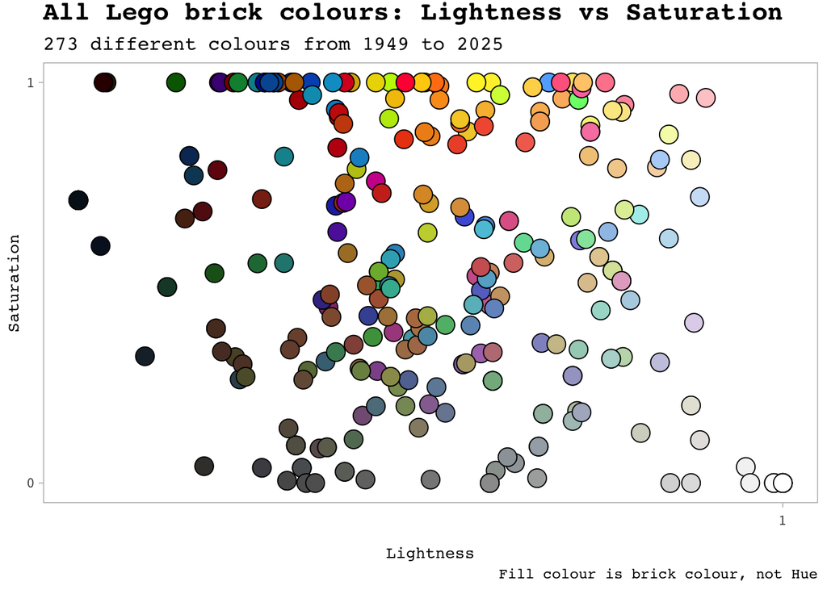

All the Lego brick colours. Saturation vs Lightness, fill is brick colour (not hue).

```r
# Saturation vs Lightness, Fill <- Hue
ggplot() +
  geom_point(data = data_from_mysql,
             mapping = aes(x = L, y = S, fill = name),
             shape = 21,
             stroke = 0.5,
             size = 5,
             colour = "black",
             alpha = 1.0) +
  scale_fill_manual(values = fill_colour_value_mapping_byName) +
  scale_x_continuous(breaks = c(0, 1)) +
  scale_y_continuous(breaks = c(0, 1)) +
  labs(title = "All Lego brick colours: Lightness vs Saturation",
       subtitle = "273 different colours from 1949 to 2025",
       x = "Lightness",
       y = "Saturation",
       caption = "Fill colour is brick colour, not Hue") +
  theme(panel.grid.major = element_blank(),
        panel.grid.minor = element_blank())
```

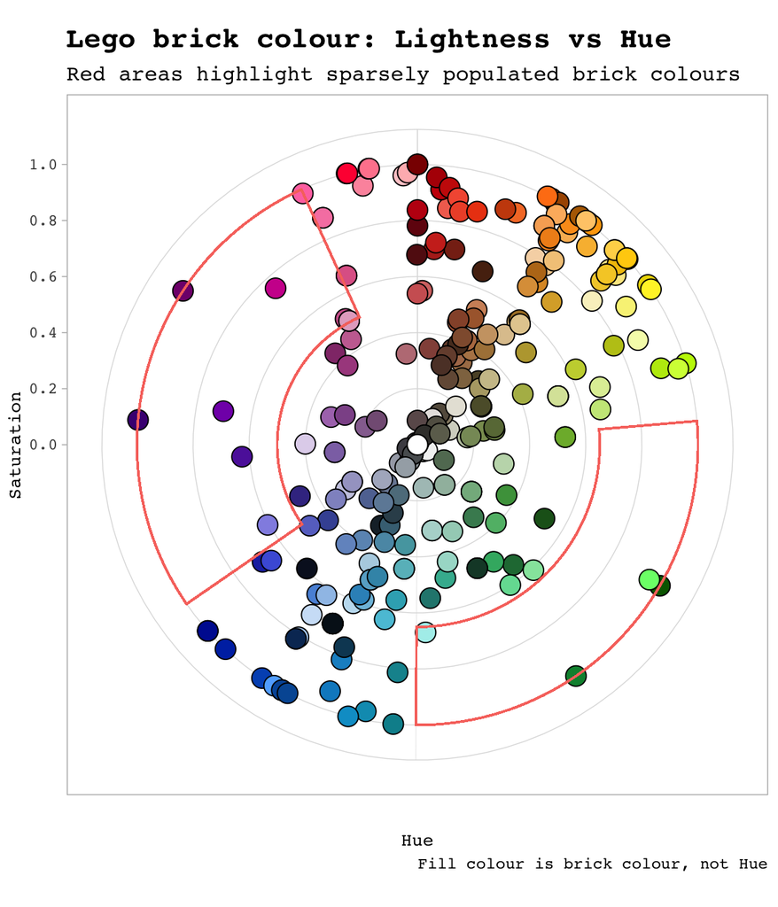

All the Lego brick colours. Saturation vs Hue, fill is brick colour (not hue).

```r
# Radial: Hue vs Saturation, fill <- Hue
ggplot(data = data_from_mysql,
       mapping = aes(x = H, y = S, fill = name)) +
  geom_point(shape = 21,
             stroke = 0.5,
             size = 5,
             colour = "black",
             alpha = 1.0) +
  coord_polar(theta = "x") +
  scale_fill_manual(values = fill_colour_value_mapping_byName) +
  scale_x_continuous(breaks = c(0, 360)) +
  scale_y_continuous(breaks = seq(0, 1, 0.2)) +
  labs(title = "Lego brick colour: Lightness vs Hue",
       subtitle = "Red areas highlight sparsely populated brick colours",
       x = "Hue",
       y = "Saturation",
       caption = "Fill colour is brick colour, not Hue") +
  geom_rect(aes(xmin = 85, xmax = 180,
                ymin = 0.65, ymax = 1,
                color = "black", fill = "None", alpha = 0.5)) +
  geom_rect(aes(xmin = 235, xmax = 335,
                ymin = 0.5, ymax = 1,
                color = "black", fill = "None", alpha = 0.5))
```

When you look at the same data with Hue on a polar axis there seems to be 2 areas that have a lower density of brick colours. These are highlighted by the read rectangles. This implies there are low numbers of bricks in the purple and green colours with 0.5 saturation.

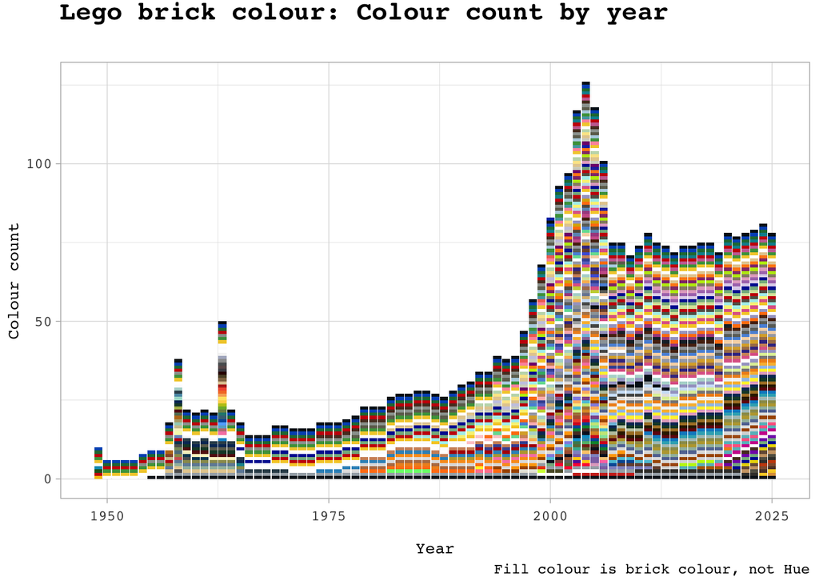

Number of Lego brick colours used per year. Fill is brick colour

```r
# Dataframe to capture each year a colour was used
data_colour_by_year <- data.frame(
  year = seq(min(data_from_mysql$y1, na.rm = TRUE),
             max(data_from_mysql$y2, na.rm = TRUE),
             1))
# default_year_count <- 0 * 1:nrow(data_colour_by_year)
for (i in 1:nrow(data_from_mysql[order(data_from_mysql$S), ])){
  name_label = data_from_mysql$name[i]
  data_colour_by_year[[name_label]] <- as.numeric(
    data_colour_by_year$year >= data_from_mysql$y1[i] &
    data_colour_by_year$year <=  data_from_mysql$y2[i])
}
data_colour_by_year <- melt(data = data_colour_by_year,
                            id.vars = "year",
                            variable.name = "name",
                            value.name = "present")
data_colour_by_year$present[is.na(data_colour_by_year$present)] <- 0

ggplot(data = data_colour_by_year,
       mapping = aes(x = year, y = present, fill = name)) +
  geom_bar(stat = "identity", position = "stack") +
  scale_fill_manual(values = fill_colour_value_mapping_byName) +
  labs(title = "Lego brick colour: Colour count by year",
       subtitle = "",
       x = "Year",
       y = "Colour count",
       caption = "Fill colour is brick colour, not Hue")
```

From the above plot I observe the following:

- A general increase in the number of colours overtime.
- An early period (1958 to 1967) of higher than the trend but constant (median 18) number of colours.
- An exponential growth in the number of colours between 1997 and 2006.
  - With the number of colours peaking over 125.
- In 2007 there was an abrupt decrease and then constant number (~75) of colours to the present.

## What I want to know…

The above leaves me with the following questions:

- What were the lego sets between 1958 and 1967 that caused the ~18 colour plateau?
- What lego sets used the lime coloured bricks for 5 years in the early 80’s?
  - Where they all the same brick?
- How do the lego themes and sets vary (if at all) with the exponential growth in colours in the early 2000’s?
- What sets / themes dominate the pink/purple bricks?
  - When were they introduced?

# Further investigation

The following section explores the aforementioned questions.

## Lego sets between 1958 and 1967

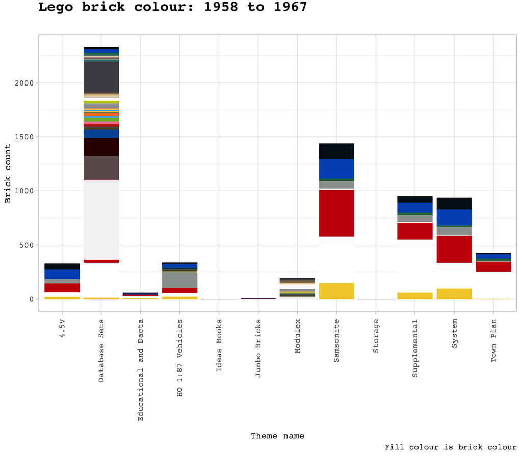

Number of bricks in themes from 1958 to 1967. Fill is brick colour.

```r
data_sixty_brickCol <- dbGetQuery(conn,
                                  "SELECT themes.name as 'themes_name',
                                          colors.name as 'colour_name',
                                          COUNT(parts.part_num) as 'part_count'
                                    FROM sets
                                      INNER JOIN themes ON sets.theme_id = themes.id
                                      INNER JOIN inventories ON sets.set_num = inventories.set_num
                                      INNER JOIN inventory_parts ON inventories.id = inventory_parts.inventory_id
                                      INNER JOIN colors ON inventory_parts.color_id = colors.id
                                      INNER JOIN parts ON inventory_parts.part_num = parts.part_num
                                  WHERE (sets.year >= 1958 AND sets.year <=1967)
                                  GROUP BY themes_name, colour_name
                                  ORDER BY themes_name;")

data_sixty_setTheme <- dbGetQuery(conn,
                                  "SELECT themes.name as 'themes_name',
                                          COUNT(sets.set_num) as 'sets_count'
                                    FROM sets
                                      INNER JOIN themes ON sets.theme_id = themes.id
                                  WHERE (sets.year >= 1958 AND sets.year <=1967)
                                  GROUP BY themes_name
                                  ORDER BY themes_name;")

data_sixty_setTheme$sets_label <- NA
for (i in 1:nrow(data_sixty_setTheme)) {
  data_sixty_setTheme$sets_label[i] <- paste(data_sixty_setTheme$sets_count[i], " sets")
}

# head(data_sixty_brickCol, n = 10)
# head(data_sixty_setTheme, n = 10)

#
ggplot(data = data_sixty_brickCol,
       mapping = aes(x = themes_name, y = part_count, fill = colour_name)) +
  geom_bar(stat = "identity", position = "stack") +
  scale_fill_manual(values = fill_colour_value_mapping_byName) +
  labs(title = "Lego brick colour: 1958 to 1967",
       subtitle = "",
       x = "Theme name",
       y = "Brick count",
       caption = "Fill colour is brick colour") +
  theme(axis.text.x = element_text(angle = 90, vjust = 0.5, hjust = 1))
```

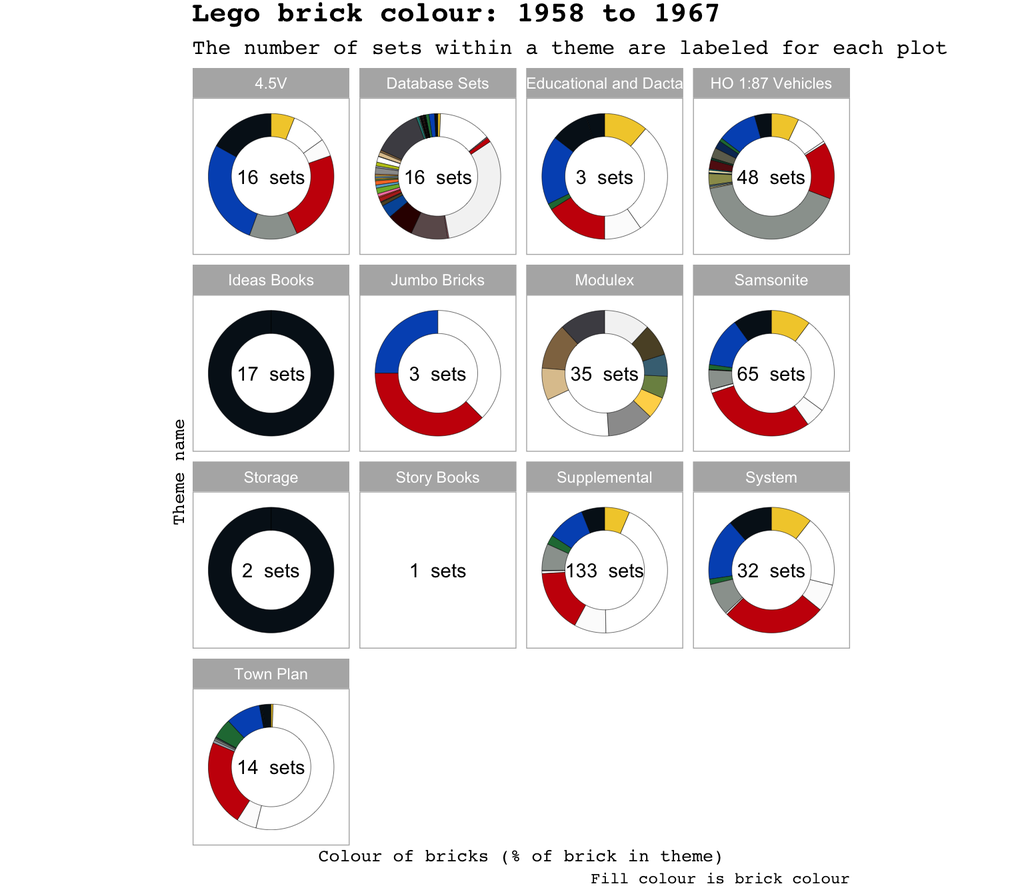

Number of bricks in themes from 1958 to 1967. Fill is brick colour.

```r
ggplot(data = data_sixty_brickCol,
       mapping = aes(x = 5, y = part_count, fill = colour_name)) +
  geom_bar(stat = "identity", position = "fill", colour = "black", linewidth = 0.1) +
  geom_text(data = data_sixty_setTheme, mapping = aes(x = -Inf, y = -Inf, fill = NA, label = sets_label)) +
  coord_polar(theta = "y") +
  scale_x_continuous(limits = c(3, NA)) +
  scale_fill_manual(values = fill_colour_value_mapping_byName) +
  facet_wrap(~ themes_name) +
  labs(title = "Lego brick colour: 1958 to 1967",
       subtitle = "The number of sets within a theme are labeled for each plot",
       x = "Theme name",
       y = "Colour of bricks (% of brick in theme)",
       caption = "Fill colour is brick colour") +
  theme(axis.text.x = element_blank(),
        axis.text.y = element_blank(),
        axis.ticks = element_blank(),
        panel.grid.major = element_blank(),
        panel.grid.minor = element_blank())
```

It can be seen in the above that most the themes have the same colours with the exception of:

- Database Sets
- HO 1:87 Vehicles
- Modulex

Also, themes like `Database Sets` & `Samsonite` in this time period are less related to the content of the sets, but logistical categorisation i.e. according to [brickipedia](https://brickipedia.fandom.com/) `Samsonite` was US manufacturer of Lego.

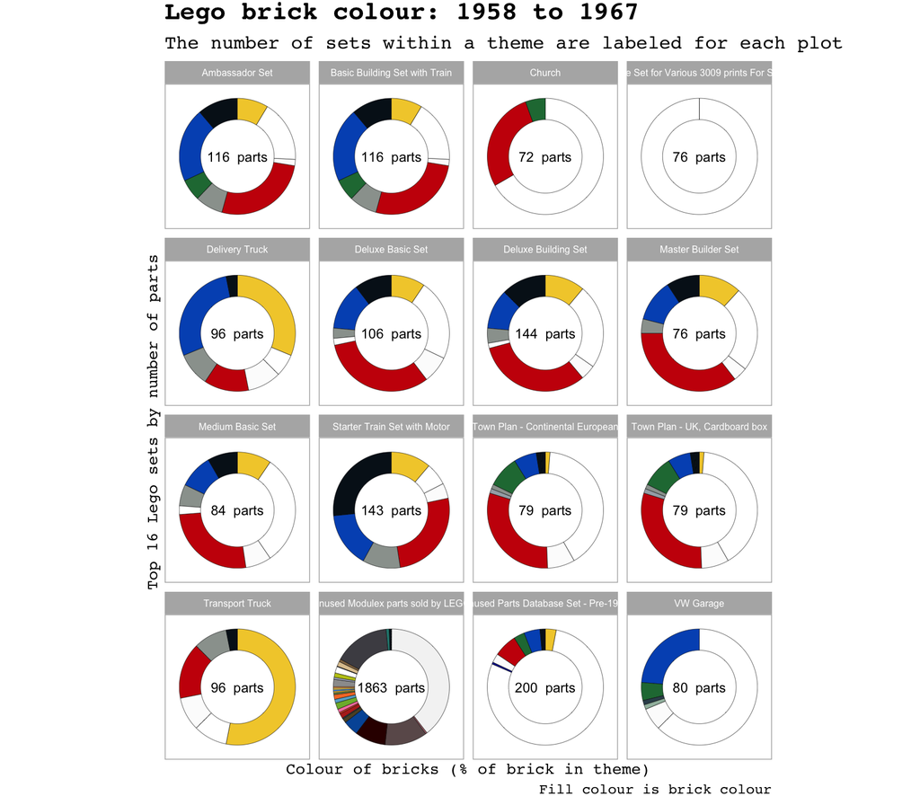

```r
data_sixty_setsParts <- dbGetQuery(conn,
                                    "SELECT sets.name as 'sets_name',
                                          COUNT(parts.part_num) as 'part_count'
                                    FROM sets
                                      INNER JOIN themes ON sets.theme_id = themes.id
                                      INNER JOIN inventories ON sets.set_num = inventories.set_num
                                      INNER JOIN inventory_parts ON inventories.id = inventory_parts.inventory_id
                                      INNER JOIN colors ON inventory_parts.color_id = colors.id
                                      INNER JOIN parts ON inventory_parts.part_num = parts.part_num
                                  WHERE (sets.year >= 1958 AND sets.year <=1967)
                                  GROUP BY sets_name
                                  ORDER BY part_count DESC;")

data_sixty_setsParts_col <- dbGetQuery(conn,
                                        "SELECT sets.name as 'sets_name',
                                                colors.name as 'colour_name',
                                                COUNT(parts.part_num) as 'part_count'
                                          FROM sets
                                            INNER JOIN themes ON sets.theme_id = themes.id
                                            INNER JOIN inventories ON sets.set_num = inventories.set_num
                                            INNER JOIN inventory_parts ON inventories.id = inventory_parts.inventory_id
                                            INNER JOIN colors ON inventory_parts.color_id = colors.id
                                            INNER JOIN parts ON inventory_parts.part_num = parts.part_num
                                        WHERE (sets.year >= 1958 AND sets.year <=1967)
                                        GROUP BY sets_name, colour_name
                                        ORDER BY part_count DESC;")

data_sixty_setsParts$part_label <- NA
for (i in 1:nrow(data_sixty_setsParts)) {
  data_sixty_setsParts$part_label[i] <- paste(data_sixty_setsParts$part_count[i], " parts")
}

# head(data_sixty_setsParts, n = 14)
# head(data_sixty_setsParts_col, n = 10)
# Select top sets
top_sets_index <- logical(nrow(data_sixty_setsParts_col))
for (i in 1:16) {
  top_sets_index <- top_sets_index | (data_sixty_setsParts_col$sets_name == data_sixty_setsParts$sets_name[i])
}

ggplot(data = data_sixty_setsParts_col[which(top_sets_index), ],
       mapping = aes(x = 5, y = part_count, fill = colour_name)) +
  geom_bar(stat = "identity", position = "fill", colour = "black", linewidth = 0.1) +
  geom_text(data = data_sixty_setsParts[1:16, ], mapping = aes(x = -Inf, y = -Inf, fill = NA, label = part_label), size = 3) +
  coord_polar(theta = "y") +
  scale_x_continuous(limits = c(3, NA)) +
  scale_fill_manual(values = fill_colour_value_mapping_byName) +
  facet_wrap(~ sets_name) +
  labs(title = "Lego brick colour: 1958 to 1967",
       subtitle = "The number of sets within a theme are labeled for each plot",
       x = "Top 16 Lego sets by number of parts",
       y = "Colour of bricks (% of brick in theme)",
       caption = "Fill colour is brick colour") +
  theme(axis.text.x = element_blank(),
        axis.text.y = element_blank(),
        axis.ticks = element_blank(),
        panel.grid.major = element_blank(),
        panel.grid.minor = element_blank(),
        strip.text = element_text(size = 6))
```

**Addressing the original question** of what makes up the bricks between 1958 and 1967, the majority of parts are in an ‘unused’ category (`Unused Modulex parts sold by LEGO` 1863 parts & `Unused Parts Database Set - Pre-1965` 200 parts). As the number of parts in only those in the set, as oppose to those made or those sold, these sets are assumed not to have dominated the market in this period. So the next the next sets with the most parts are:

- Deluxe Building Set with 144 parts
- Starter Train Set with Motor with 143 parts
- Basic Building Set with Train with 116 parts

## Lime coloured bricks in the early 80’s

With a quick enquiry (see below) is can be seen that there were 2 colours that were introduced and ended in the 80’s:

- Fabuland Orange
- Fabuland Lime

```r
# Find colours only in the 80's
head(data_from_mysql$name[data_from_mysql$y1 > 1980 &
                       data_from_mysql$y2 < 1990 &
                       !is.na(data_from_mysql$y1)], n = 10)
```

```
## [1] "Fabuland Orange" "Fabuland Lime"
```

*First 10 results showing `parts` and `sets` that are Fabuland Lime.*

```r
data_lime_bricks <- dbGetQuery(conn,
                                "SELECT sets.set_num as 'sets_num',
                                          sets.name as 'sets_name',
                                          colors.name as 'color_name',
                                          parts.name as 'part_name'
                                    FROM sets
                                      INNER JOIN themes ON sets.theme_id = themes.id
                                      INNER JOIN inventories ON sets.set_num = inventories.set_num
                                      INNER JOIN inventory_parts ON inventories.id = inventory_parts.inventory_id
                                      INNER JOIN colors ON inventory_parts.color_id = colors.id
                                      INNER JOIN parts ON inventory_parts.part_num = parts.part_num
                                  WHERE colors.name = 'Fabuland Lime';")

head(data_lime_bricks, n = 10)
```

```
##    sets_num         sets_name    color_name                           part_name
## 1    3715-1      Flower Stand Fabuland Lime    Fabuland, Equipment Watering Can
## 2    3781-1 Maximillian Mouse Fabuland Lime    Fabuland, Equipment Watering Can
## 3    3707-1        Clover Cow Fabuland Lime    Fabuland, Equipment Watering Can
## 4    2770-1        Play House Fabuland Lime                 Duplo Bathroom Sink
## 5    2770-1        Play House Fabuland Lime                       Duplo Bathtub
## 6    2770-1        Play House Fabuland Lime          Duplo Shower Head on Stand
## 7    2770-1        Play House Fabuland Lime      Duplo Mirror with Silver Print
## 8    2770-1        Play House Fabuland Lime          Duplo Toilet (without Rim)
## 9    2754-1          Bathroom Fabuland Lime Duplo Chair 2 x 2 x 2 with One Stud
## 10   2754-1          Bathroom Fabuland Lime           Duplo Cabinet 2 x 2 x 1.5
```

So, to answer the proposed question: In the above it can be seen that the ‘Fabuland Lime’ was used to make 8 different bricks. 7 bricks made up parts of a duplo bathroom from 2 sets and the final brick was a watering can used across 3 sets.

[figure not shown]

Image of Lego set with Fabuland Lime bricks.

## Early 2000’s Lego trends

It is known [(example report used as the main reference in this section)](https://bricknerd.com/home/legos-financial-history-part-1-the-ides-of-march-2000-to-2001-7-27-23) that in the early 2000’s Lego as a business was struggling, this struggle peaked with a reported *1.9 billion kr* deficit in their 2004 annual report. However, the business is held as an exempla of a business turn around of with a reported *13.8 kr billion* profit in 2022.

The turn around in 2005 is accredited to focusing on ‘the bricks’ (what Lego does well) which was still rated child’s toy.

So, how are these times of turmoil reflected in the rebrickable data base?

```r
# Get data relating to themes and sets over time
data_themes <- dbGetQuery(conn,
                          "SELECT themes.name as 'themes_name',
                                  MIN(sets.year) as 'min_year',
                                  MAX(sets.year) as 'max_year',
                                  COUNT(sets.name) as 'num_of_sets'
                            FROM sets
                            INNER JOIN themes ON sets.theme_id = themes.id
                          GROUP BY themes_name
                          ORDER BY themes_name;")

# Number of sets per year the theme existed
data_themes$sets_per_year <- data_themes$num_of_sets / (1 + data_themes$max_year - data_themes$min_year)

# Plot total data per year
data_themes_by_year <- data.frame(
  year = seq(min(data_themes$min_year, na.rm = TRUE),
             2024, 1) # Limit years to 2024
)

for (i in 1:nrow(data_themes)){
  name_label = data_themes$themes_name[i]
  data_themes_by_year[[name_label]] <- as.numeric(
    data_themes_by_year$year >= data_themes$min_year[i] &
    data_themes_by_year$year <=  data_themes$max_year[i])
}
data_themes_by_year <- melt(data = data_themes_by_year,
                            id.vars = "year",
                            variable.name = "name",
                            value.name = "present")
data_themes_by_year$present[is.na(data_themes_by_year$present)] <- 0
```

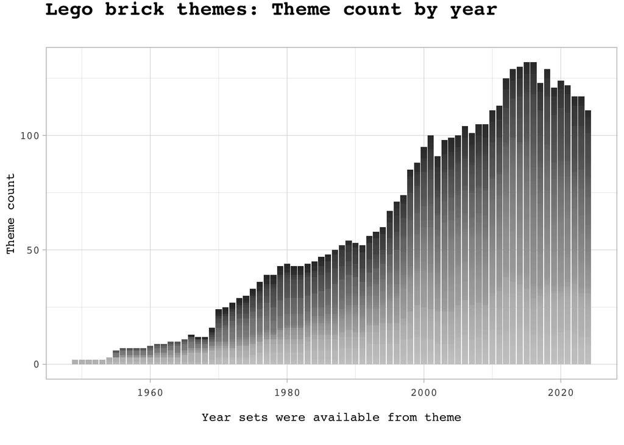

Number of themes vs the year sets were available

```r
ggplot(data = data_themes_by_year,
       mapping = aes(x = year, y = present, fill = name)) +
  geom_bar(stat = "identity", position = "stack") +
  labs(title = "Lego brick themes: Theme count by year",
       subtitle = "",
       x = "Year sets were available from theme",
       y = "Theme count",
       caption = "") +
  scale_fill_grey()
```

The above shows that the number of themes has increased from 1949 to a peak around 2015/2016 (both with 133 themes). This has then dropped to 112 themes by 2024. Prior to 2004 (largest reported business deficit) there was a increase rate in theme introduction starting in 1990 and plateauing in early 2000’s. Any correlation of this increased rate to the 2004 deficit is unknown, however it is [(reported)](https://brickipedia.fandom.com/wiki/Licensed_themes) that Lego started to license the rights to popular entertainment franchises (like Star Wars in 1999, various Disney 2000, Harry Potter 2001) with there being 8 & 13 new licenses in 2015 & 2016 respectively which align with the peak number of themes.

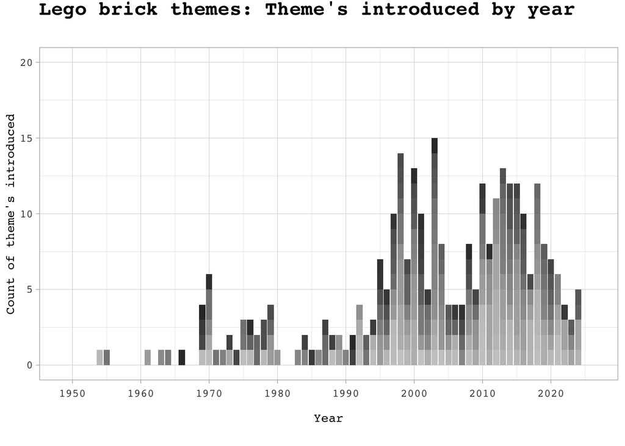

2 Plots showing the number of themes introduced and retired between 1949 and 2024.

```r
# Original plots - changed to display difference plot below
ggplot(data = data_themes[data_themes$min_year < 2025 & data_themes$max_year < 2025, ],
       mapping = aes(x = min_year, fill = themes_name)) +
  geom_bar(stat = "count", position = "stack") +
  labs(title = "Lego brick themes: Theme's introduced by year",
       subtitle = "",
       x = "Year",
       y = "Count of theme's introduced",
       caption = "") +
  scale_x_continuous(limits = c(1949, 2026), breaks = seq(1950, 2025, 10)) +
  scale_y_continuous(limits = c(0, 20)) +
  scale_fill_grey()
```

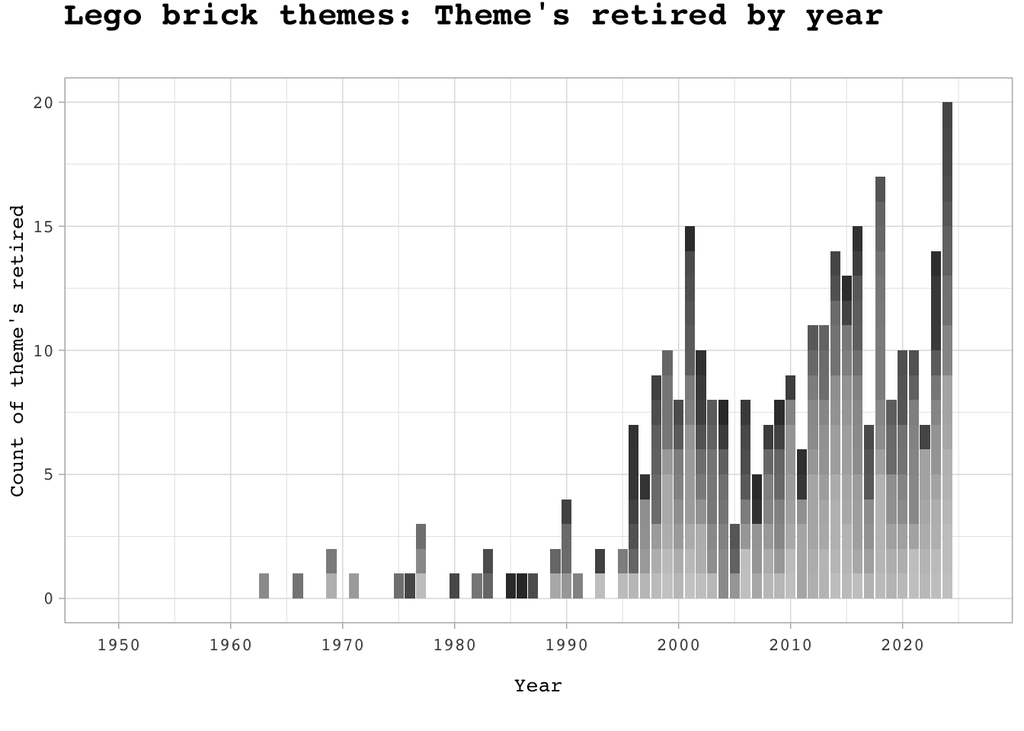

2 Plots showing the number of themes introduced and retired between 1949 and 2024.

```r
ggplot(data = data_themes[data_themes$min_year < 2025 & data_themes$max_year < 2025, ],
       mapping = aes(x = max_year, fill = themes_name)) +
  geom_bar(stat = "count", position = "stack") +
  labs(title = "Lego brick themes: Theme's retired by year",
       subtitle = "",
       x = "Year",
       y = "Count of theme's retired",
       caption = "") +
  scale_x_continuous(limits = c(1949, 2026), breaks = seq(1950, 2025, 10)) +
  scale_y_continuous(limits = c(0, 20)) +
  scale_fill_grey()
```

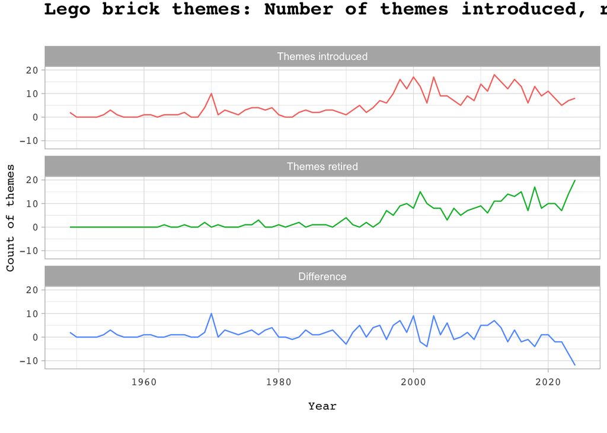

2 Plots showing the number of themes introduced and retired between 1949 and 2024.

```r
# Updated plots of themes introduced and retired per year
data_themes_totalPerYear <- data.frame(
  year = seq(min(data_themes$min_year, na.rm = TRUE),
             2024, 1) # Limit years to 2024
)

for (i in 1:nrow(data_themes_totalPerYear)){
  data_themes_totalPerYear$intro[i] <- sum(data_themes$min_year == data_themes_totalPerYear$year[i])
  data_themes_totalPerYear$retir[i] <- sum(data_themes$max_year == data_themes_totalPerYear$year[i])
}
data_themes_totalPerYear$diff <- data_themes_totalPerYear$intro - data_themes_totalPerYear$retir

data_themes_totalPerYear <- melt(data = data_themes_totalPerYear,
                                 id.vars = "year",
                                 variable.name = "var",
                                 value.name = "value")

plt_label <- c("intro" = "Themes introduced", "retir" = "Themes retired", "diff" = "Difference")
ggplot(data = data_themes_totalPerYear, mapping = aes(x = year, y = value, colour = var)) +
  geom_line() +
  facet_wrap(~ var, ncol = 1, labeller = as_labeller(plt_label)) +
  labs(title = "Lego brick themes: Number of themes introduced, retired and difference per year",
       subtitle = "",
       x = "Year",
       y = "Count of themes",
       caption = "")
```

The above show that until 1990 there was a consistent increase in themes with changes per year being less than 4 themes, the exception being 1970 where there were 10 themes introduced. However, in 1995 there was an increased activity in both themes introduced and retired. As noted above, the introduction of licensing entertainment franchises in 1999 could explain the increased levels of theme introduction and retirement as franchises become and loose popularity.

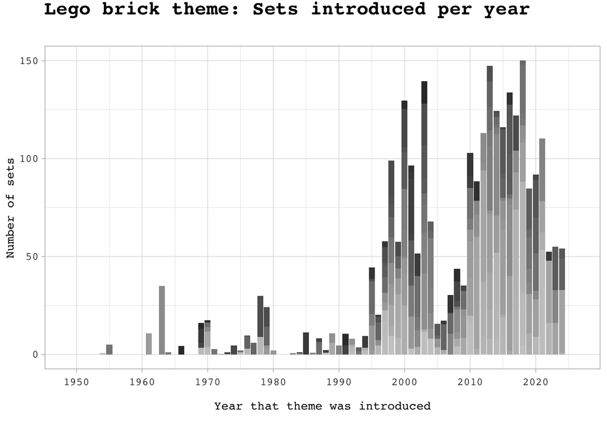

```r
ggplot(data = data_themes[data_themes$min_year < 2025 & data_themes$max_year < 2025, ],
       mapping = aes(x = min_year, y = sets_per_year, fill = themes_name)) +
  geom_bar(stat = "identity", position = "stack") +
  labs(title = "Lego brick theme: Sets introduced per year",
       subtitle = "",
       x = "Year that theme was introduced",
       y = "Number of sets",
       caption = "") +
  scale_x_continuous(limits = c(1949, 2026), breaks = seq(1950, 2025, 10)) +
  scale_fill_grey()
```

The above shows the average number of sets available before 1995 was below 50 (mostly below 25). After 1995, there are then 2 peaks in available sets around 2000 and 2015 with peak values greater than 130 sets and a dip in between these peaks 2005 where sets available were less than 25 sets are available.

Like the theme trends discussed above, the dip in the number of available sets in 2005 could be a result of activities to address the record deficit that the Lego company experience at this point in time.

Also, looking back at the colour vs year plot in the *exploration of the data* section above, the peak number of available colours was in 2004 and since 2007 the number of colours has stayed around 75. This reduction and constant number of colours could be the result of an efficiency exercise to streamline supply of plastics.